# Statistical inference

CRM week 3

Charles Lanfear

2026-10-27

## Today

- Regression and Models
- Inferential Statistics
  - Hypothesis Testing
  - Theoretical Distributions
  - Properties of Means
  - Problems with Hypothesis Testing
- Many wordy slides

# Regression

[figure not shown]

## Correlations

Correlations ( $R$ ) summarize associations between continuous variables:

- Range from -1 to 1
  - 0: No *linear association*
  - -1 and 1: Perfect linear associations

$R^2$, the **coefficient of determination**, indicates the *proportion* of variation in one variable **linearly** predicted by another

- Range from 0 to 1
  - 0: Neither explains each other (linearly)
  - 1: They perfectly explain (or determine) each other

*A correlation of 0.5 between $x$ and $y$ indicates 25% of the variation in $y$ is “explained” by $x$ (and vice versa)*

## Visualizing correlations

[figure not shown]

## Last week’s correlation

[figure not shown]

This is a strong relationship: About 66% of the variation is explained

But what is the *substantive* interpretation?

If pop density is 20, what do we expect crime to be?

*What we want is a **model** to estimate how pop density predicts crime*

# Modeling

[figure not shown]

## The DGP

When doing research, we’re usually interested in saying something about how some part of the real world works

The distributions of data we observe are the result of a real-world process we cannot directly observe

We call this the **data generating process** (DGP)

**Models** aim to approximate this data generating process mathematically to allow us to make quantitative statements about how the world works

Most of the time, in any given project, we’re really interested in an **estimate** of just one part of the DGP or one characteristic of the population:

- A distribution or measure of central tendency
- A correlation or other association
- A *causal effect* (next week!)

## Estimation

Going from data to an estimate is a process involving three components:

- **Estimand**: the real-world quantity we want to measure
- **Estimator**: the procedure we use to calculate an estimate using data
- **Estimate**: the measured quantity approximating our estimand

Any given estimate consists also of three components:

$$Estimate = Estimand + Bias + Noise$$

**Noise** comes from *randomness* in the real world or sampling (today)

**Bias** comes from *using the wrong estimator* (next week)

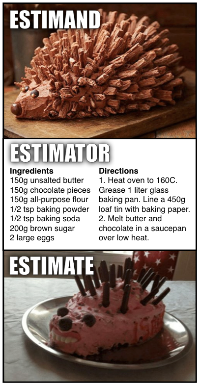

Credit: [Richard McElreath](https://twitter.com/rlmcelreath/status/1582368904529137672)

## Regression

Regression is an estimation method for *fitting lines* to data

Regression just summarizes a relationship between variables using a line

- e.g., predicting $Y$ using $X$
- The variable being predicted is the **dependent** or **outcome** variable
- The variables used for prediction are **independent** or **explanatory** variables, sometimes called **covariates** or **regressors**

The regression line is the **conditional expectation** of the dependent variable

- e.g., the expected value (mean) of $Y$ for each value of $X$

## A regression line

[figure not shown]

“If population density is 20, we expect the crime rate to be about 41”

## Model fitting

The regression line represents an **estimate** of the association between population density and the crime rate (the estimand we want)

The estimator used for **fitting** this line has two parts:

1. The model—the shape of the line (e.g., straight) and our choice of covariates
2. The estimation method—the maths to fit that shape to the data, e.g., **ordinary least squares** (OLS)

OLS draws a line through the data that minimizes the *sum of squared residuals*

- Residuals are the $Y$ distances between the line and each point
- OLS draws the line where the sum of squared residuals is *smallest*

## Residuals

[figure not shown]

[See here for an interactive explanation](https://setosa.io/ev/ordinary-least-squares-regression/)

## Regression equation

Regression lines are defined by **parameters**: the **intercept** and **slope(s)** .

Regression line equations look like this:

$$y_i = a + b x_i + e_i$$

$a$ is the **intercept**, the expected value of $y$ when $x = 0$

$b$ is a **slope**, how the mean of $y$ rises for each increase in $x$

$e_i$ is the **residual**

- The difference between prediction ( $a + bx$ ) and *each value* of $y$
- The square of this is what OLS is trying to minimize

## Regression equation

[figure not shown]

## Predictions

The regression line is a set of predictions of $Y$ for every value of $X$

The regression formula tells us those predictions:

$$CrimeRate = -20.8 + 3.09 PopDensity$$

We expect $CrimeRate$ to be 3.09 higher for every additional unit of $PopDensity$

When $PopDensity$ is zero, the expected $CrimeRate$ is $-20.8$

If $PopDensity$ is $20$, then we expect $CrimeRate$ to be:

$$41 = -20.8 + 3.09*20$$

*The next question is whether this strong association likely holds in the population*

## A note on notation

For theoretical models, i.e., what occurs in the *population*, we usually use Greek for the **parameters** (estimands!) but Latin for the observed data:

$$y_i = \alpha + \beta x_i + \epsilon_i$$

But once we estimate those parameters from data, i.e., show what occurs in the *sample*, we typically use Latin for those **estimates** (they’re *observed*!):

$$y_i = a + b x_i + e_i$$

Sometimes, though, you’ll see Greek wearing hats for estimates:

$$y_i = \hat{\alpha} + \hat{\beta} x_i + \hat{\epsilon}_i$$

# Inferential statistics

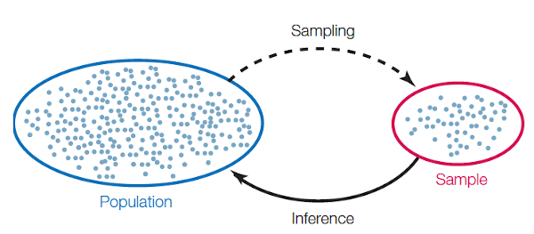

## Null hypothesis testing

Recall that we want to learn about the true data generating process (DGP)

We cannot observe it directly, but we can use data to infer things about it

**Hypothesis testing** is one approach to learning about DGPs

The basic idea:

- Make an informed guess—a **hypothesis**—about what the DGP looks like
  - **Theory** is about DGPs!
- Test if it is likely observed data were created by the hypothetical DGP
- If it seems unlikely, we **reject** our hypothesis

In short, we get closer to the truth by rejecting false explanations

- *via negativa*: Knowledge by subtracting what is wrong

## Significance testing

The simplest hypothesis testing is **null hypothesis significance testing**:

1. State hypotheses about estimand:
   - **Null Hypothesis**: There is no relationship
   - **Alternative Hypothesis**: There is a relationship (at all or directional)
2. Make an estimate
3. Test how likely this estimate would be *if our null hypothesis is true*
   - We choose a threshold for what we consider “unlikely”, e.g., less than 5% chance
4. Either reject or fail to reject the null; we do not *accept* the null

*When we reject the null, we’re confident our result is not just due to **noise***

## Frequentism

Hypothesis testing is rooted in the **frequentist** paradigm of statistics

Frequentism is based on the logic of *infinite* random sampling

- For a given DGP, imagine randomly sampling from the population *forever*
- The distribution of values in the samples (e.g., the means) would follow a known **theoretical distribution**
  - i.e., we know how likely it is to obtain any particular estimate *if the theoretical DGP is true*
- Based on these theoretical distributions, we assess how (un)likely observed results are under a given hypothesis
- Importantly, *all of these rely on properties of random sampling*
  - Non-random samples lead to **bias**

# Theoretical distributions

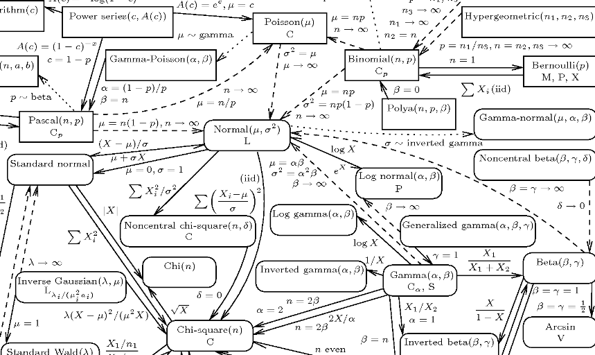

## Coin flipping

In theory, a normal coin is equally likely to land on heads or tails

If we flipped it 20 times and got 13 heads, would we think it is a fair coin?

What about 15 heads?

If the coin is truly fair, it should have a 0.5 probability of coming up heads

- Our null hypothesis is the coin is fair and has a heads probability of 0.5
- Our alternative is it is *unfair*—likely to give more or fewer heads than 0.5

We can calculate how likely it is to observe any particular number of heads flips if our null hypothesis is true

- e.g., how likely is it to get 15 heads on 20 flips with a fair coin
- We can do this just by tabulating every possible outcome of 20 coin flips

## Ways to get…

We’re *1,000 times* more likely to get 10 heads than 2 heads!

The probability we get any particular number of heads is can be described by a theoretical distribution: the **binomial distribution**

## Binomial distribution

If we flip a fair coin 20 times, the binomial distribution says we’re this likely to see each count of heads:

[figure not shown]

Roughly 95% of the time, we’d expect to see between 6 and 14 heads.

5% or less of the time would we see 5 or fewer or 15 or more.

## p-values

The **p-value** is the probability of observing a result at least as extreme as our estimate if the null hypothesis (a fair coin) were true.

- The p-value for 15 out of 20 (75%) flips being heads is 0.041
- A fair coin would give us a result as far from 50% as this 1 in 25 times
- p-values are typically calculated using a **test statistic** derived from a theoretical distribution (e.g., $t$ or $\chi^2$ tests)

The *p-value* is *not* the probability our null hypothesis is true

All a p-value tells us is how *frequently* the theoretical distribution we chose would generate the data we observe

- p-values are only valid if we’ve chosen the right theoretical distribution

## Confidence levels

We say something is **statistically significant** when the p-value is below a chosen value ($p < \alpha$), e.g., $p<.05$

$\alpha$ is the rejection threshold, corresponding to a **confidence level** of $1-\alpha$

- The threshold for rejecting the null distribution as a source of our data
- e.g., 95% confidence corresponds to $\alpha=.05$

$\alpha$ indicates our “comfort” in rejecting the null when it is *true*

- e.g., $\alpha=.05$ means we reject a true null 5% of the time

*Choice of confidence levels is context-specific*

## Errors

Lower confidence levels lead to more **false positive** or **Type I error**

- Rejecting the null when it is true

Higher levels of confidence reduce false positives, but lead to more **false negatives** or **Type II errors**

- Failing to reject the null when it is false

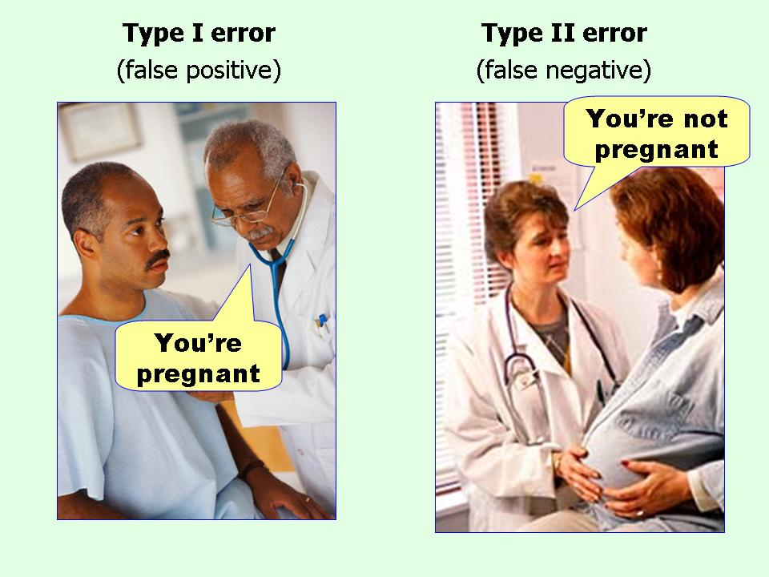

Credit: [Paul Ellis](https://effectsizefaq.com/2010/05/31/i-always-get-confused-about-type-i-and-ii-errors-can-you-show-me-something-to-help-me-remember-the-difference/)

## Cross-tabs

Cross-tabs are used to show associations between categorical variables

Is there an association?

|  | Area |  |
| --- | --- | --- |
| Disadvantage | Rural | Urban |
| Low | 63 | 39 |
| Medium | 49 | 48 |
| High | 41 | 60 |

What does no association look like?

|  | Area |  |
| --- | --- | --- |
| Disadvantage | Rural | Urban |
| Low | 66 | 66 |
| Medium | 45 | 45 |
| High | 39 | 39 |

*Rural and urban areas equally probable to be in each level of disadvantage*

But we could get different probabilities just from randomness in sampling.

## Chi-square test

The chi-square ( $\chi^2$ ) asks: How likely would we be to draw a sample with this strong an association if there were no relationship in the population?

|  | Area |  |
| --- | --- | --- |
| Disadvantage | Rural | Urban |
| Low | 63 | 39 |
| Medium | 49 | 48 |
| High | 41 | 60 |

Here we get a test statistic of 9.11 (df=2) corresponding to a statistically significant (at 95% confidence) p-value of 0.010.

*Disadvantage and Area are more strongly related in this sample than is likely to occur due only to sampling noise.*

- i.e. this is evidence for an association in the population

# Focusing on means

[figure not shown]

## Means

When we want to infer something about the population from a sample, we often focus on some kind of mean

This is because means have a useful sampling property, described by the **central limit theorem**:

*No matter what the distribution* of the variable in the population you sample from, the distribution of the **means** of all samples will be normally distributed around the population’s mean*

*This sounds weird because it is weird*

*It makes slightly more sense visually*

## Illustration

Imagine this is the distribution of a variable $X$ ranging $(0,1)$ in the population:

[figure not shown]

The mean is in red, but the shape is definitely not a bell curve

## One sample

Let’s say we sample 100 observations from it and take the mean

[figure not shown]

Our estimate is great with only $N=100$! But if we couldn’t compare to the population, how would we know that?

## Many samples

If we take a ton<sup>1</sup> of samples (n=100 each) and calculate all their means, their distribution looks like this—most are pretty accurate: 95% of them are between 0.55 and 0.65!

[figure not shown]

*Okay, sure, but what about **weird** distributions?*

[^1]: 100,000 in this case!

## wat

Okay, look at this bimodal monster:

[figure not shown]

There’s barely any data near the mean at all!

## Huh, okay

This is the sampling distribution of the means we get from *that*

[figure not shown]

*Yep, still works—just noisier!*

## This is nice

Sample means being normally distributed around the population mean is *extremely useful*

This means we can use the normal distribution (or something related to it) as a theoretical distribution in many different situations

- Population means
- Differences in means
- Correlations
- Regression parameters
- Categorical associations ($\chi^2$!)

In particular, we can assess the precision and statistical significance of estimates

## Standard errors

**Standard errors** measure the precision of our sample estimates

Smaller standard errors indicate more precise estimates

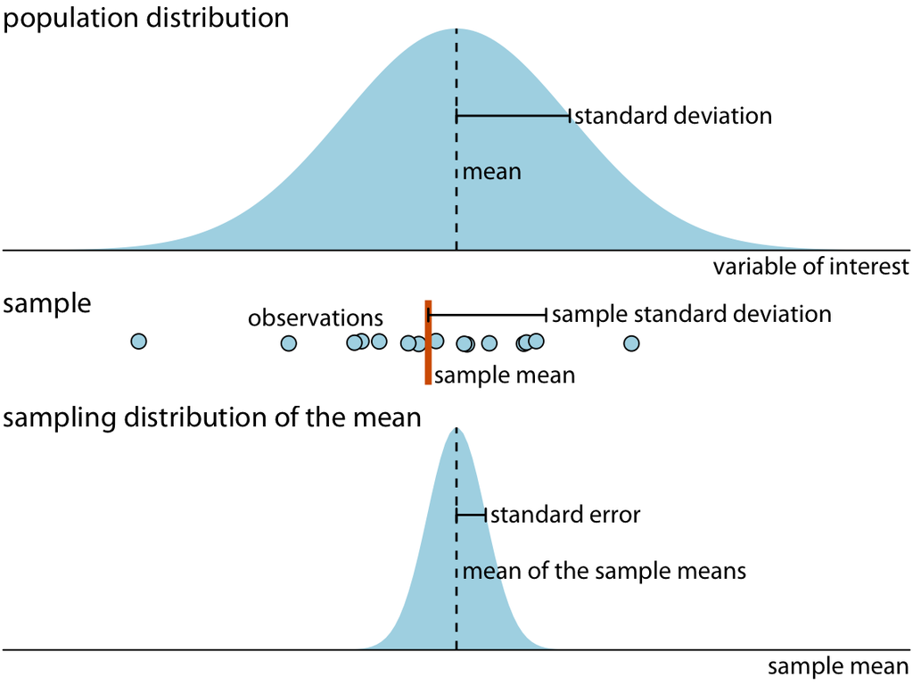

Larger sample sizes mean smaller standard errors

Image credit: [Claus Wilke](https://clauswilke.com/dataviz/visualizing-uncertainty.html)

## Confidence intervals

We can calculate confidence intervals from the standard error

Intuitively, **confidence intervals** (CI) are a range of *reasonably likely* values for the estimand, given our observed sample values

- Based on a **confidence level**, e.g. 95%
- 95% CI of (5.2, 7.5) is compatible with estimands between 5.2 and 7.5

Less intuitively, if you re-estimated the quantity with new data infinitely, 95% of the 95% CIs would overlap the true estimand

Confidence intervals are closely related to p-values:

- The CI will not include zero if the p-value is significant

[Confidence interval example](https://rpsychologist.com/d3/CI/)

## Our regression

Here is a table of results from our regression earlier

| Term | Estimate | Std Error | Statistic | P Value | Conf Low | Conf High |
| --- | --- | --- | --- | --- | --- | --- |
| Pop Density | 3.09 | 0.13 | 23.54 | 0.00 | 2.84 | 3.35 |
| (Intercept) | -20.78 | 2.09 | -9.94 | 0.00 | -24.89 | -16.66 |

This suggests a strong, statistically significant relationship between density and the crime rate

Do we believe this is a good model, however?

If for some reason we’re only interested in the (unconditional, linear) association between density and the crime rate, this might be just fine!

*Next week we’ll get into estimates we might actually want to know*

## Confidence interval of the line

Small standard errors give a narrow confidence interval around the line:

[figure not shown]

Note it is not an interval containing 95% of the *data points*

## Hypothesis testing issues

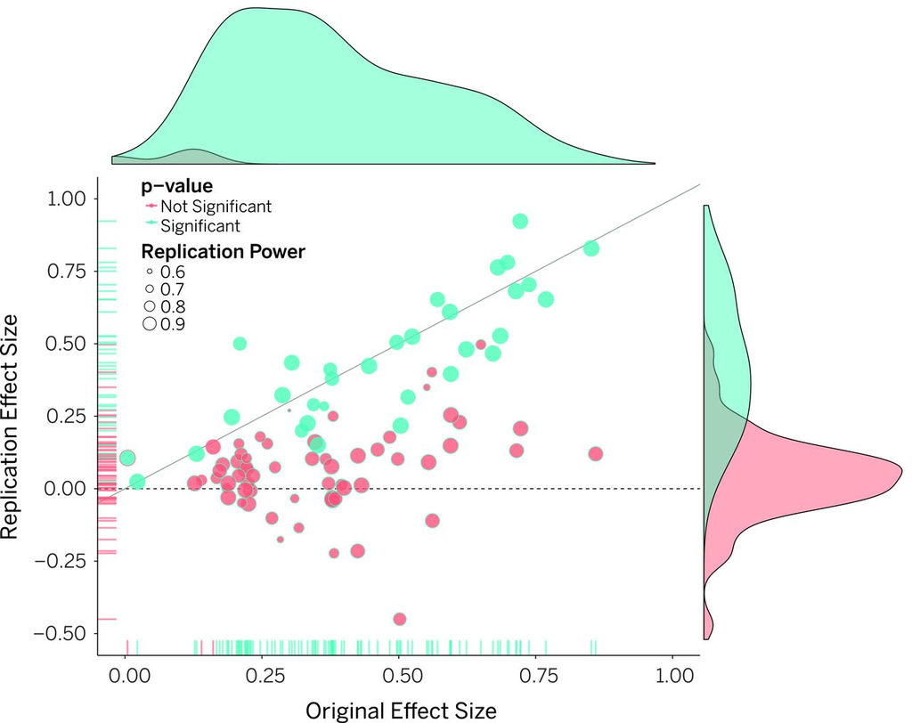

Source: Open Science Collaboration (2015) “Estimating the reproducibility of psychological science”

## Unethical practices

There are intense pressures on researchers to produce both *high volume* and *high impact* research

It is trivial to perform many analyses, cherry-pick significant ones, then submit only those for review

- The scientific community observes only what is submitted

Similarly, one can invest enormous time and money into a project and receive null results

- Inability to publish these is frustrating and damaging to careers
  - *publish or perish*

## Screening effects

Due simply to random noise, even perfectly designed ethical research will routinely produce false positives at conventional confidence levels

Journal have historically declined my submissions with null findings

- Articles are rejected for being “not novel”
- Articles are never submitted because authors know they will be rejected

Conversely, journals (and the media) reward “novel” significant results

This leads to a number of problems:

- Literatures filled with false positives and missing true negatives
- Absence of replication studies (likely null findings)
- Average estimates greater in magnitude than the real estimands

## Responding

The social sciences are begrudgingly moving to address these problems:

- Estimating publication bias
- Pre-registration of analyses and registered reports
- Requirements for computational reproducibility
- Replication studies
- Publishing null findings

These all work best to address researchers behaving *ethically*

It can be *very hard* to detect unethical researchers

- As is the case for many types of white-collar crime, it is mainly the incompetent who get caught

## Incompetent… but rich

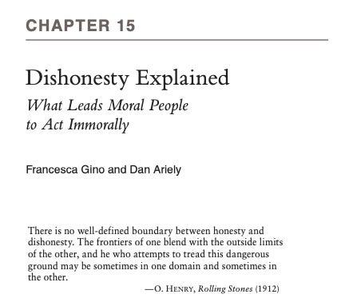

[figure not shown]

Answer: *Yes*

## Wrap-up

Regression is just fancy line drawing

- The line represents the conditional mean
- We can use the line to make predictions

Hypothesis tests compare observed data and to theoretical distributions

- Statistical significance means the observed data are unlikely to have come from the chosen theoretical distribution

Be wary of the scientific literature

- Constraints and incentives result in many false positives
- Enforcement of research ethics is difficult

## Next time

Causality and theory testing!

You’re almost dome with me!<sup>1</sup>

[^2]: In CRM, sorry about IQA, haha